# Analysis of the Hourly Concentration of NO2 Particles in the Air of Roads

## Group 10

s3838647 - Sneha Chakravarthy  
s3855148 - Jaim Zacharia  
s3805530 - Shrestha Ghosh

**1**.Source and Description  
**1.1** Data Source  
**1.2** Project Objective  
**1.3** Target Feature  
**1.4** Descriptive Features  
**2.** Data Preparation  
**2.1** Data Cleaning and Transformation  
**2.2** Summary Statistics  
**2.3** Continuous Features  
**3.** Data Exploration  
**3.1** Univariate Visualisation  
**3.1** Multivariate Visualisation  
**4.** Statistical Modelling and Performance Evaluation  
**4.1** Full Model  
**4.2** Full Model Diagnostic Checks  
**4.3** Backwards Feature Selection  
**4.4** Reduced Model Diagnostic Checks  
**5.** Summary and Conclusions  
**6.** References

## Source and Description

### Data Source

The dataset was sourced from the Open Machine Learning Repository at https://www.openml.org/d/547 (Aldrin, 2004).

The data are a subsample of 500 observations from a data set that originate in a study where air pollution at a road is related to traffic volume and meteorological variables, collected by the Norwegian Public Roads Administration. The response variable consist of hourly values of the logarithm of the concentration of NO2 (particles), measured at Alnabru in Oslo, Norway, between October 2001 and August 2003.

### Project Objective

The goal of this project is to analyze the predictability of the hourly concentration of nitrogen dioxide particles in the air with a reasonable margin of error using multiple linear regression with just traffic volume and meteorological variables. We also want to determine the variables from the dataset that are actually required for predicting the hourly concentration of nitrogen dioxide.

Statistical modelling of the training data, which predicts the target feature, achieves the goal.

Before modelling, we clean and prepare data, followed by an exploration of dataset features and their inter-relationships.

After modelling, diagnostic checks of the model determine if the model is reliable and if we can predict the target variable using just the given dataset features.

### Target Feature

Our target feature is Nitrogen Dioxide (NO2) concentration, which is a continuous numerical feature. Hence, our project is on a regression problem.

### Descriptive Features

The variable descriptions below are from the dataset:

| Feature Name | Data Type | Units | Description |
| --- | --- | --- | --- |
| `no2_concentration` | continuous | particles | concentration of nitrogen dioxide |
| `cars_per_hour` | discrete | count | number of cars per hour |
| `temperature_at_2m` | continuous | degrees C | temperature at 2m above the ground |
| `wind_speed` | continuous | meters/second | speed of the wind |
| `temperature_diff_2m_25m` | continuous | degrees C | temperature difference between 25m and 2m above the ground |
| `wind_direction` | discrete | degree | direction of the wind between 0 and 360 |
| `hour_of_day` | discrete | hour | the hour of the day between 1 and 24 |
| `day` | discrete | count | day number from October 1 2001 |

## Data Preperation

```python
import numpy as np
import pandas as pd
pd.set_option('display.max_columns', None)
import matplotlib.pyplot as plt
import seaborn as sns
import statsmodels.api as sm
import statsmodels.formula.api as smf
import patsy
import warnings
###
warnings.filterwarnings('ignore')
###
%matplotlib inline
%config InlineBackend.figure_format = 'retina'
plt.style.use("ggplot")
```

```python
data=pd.read_csv("Group10_Data.csv")
data = data.round(3)
```

```python
print(f"This dataset has {data.shape[0]} rows and {data.shape[1]} columns")
```

```
This dataset has 500 rows and 8 columns
```

```python
#Displaying randomly selected 10 rows
data.sample(10)
```

|  | no2_concentration | cars_per_hour | temperature_at_2m | wind_speed | temperature_diff_2m_25m | wind_direction | hour_of_day | day |
| --- | --- | --- | --- | --- | --- | --- | --- | --- |
| 289 | 4.237 | 7.648 | -4.1 | 2.9 | -0.4 | 85.3 | 14 | 519 |
| 296 | 1.705 | 5.112 | -4.4 | 4.2 | -0.1 | 55.0 | 4 | 119 |
| 56 | 2.425 | 5.645 | 0.3 | 7.1 | -0.1 | 69.5 | 2 | 425 |
| 158 | 3.459 | 7.941 | 4.3 | 5.6 | -0.9 | 64.0 | 12 | 174 |
| 363 | 3.791 | 7.802 | 2.5 | 5.0 | 0.1 | 135.0 | 7 | 128 |
| 325 | 3.716 | 7.986 | -2.3 | 4.2 | -0.1 | 77.0 | 18 | 399 |
| 200 | 3.182 | 6.898 | -1.4 | 4.8 | -0.1 | 72.0 | 23 | 57 |
| 65 | 4.359 | 7.763 | 9.2 | 5.7 | -0.9 | 199.0 | 14 | 212 |
| 352 | 2.890 | 7.769 | 21.1 | 4.5 | -3.6 | 285.1 | 11 | 607 |
| 486 | 4.067 | 7.732 | 2.6 | 4.2 | -0.2 | 77.9 | 14 | 514 |

### Data Cleaning and Transformation

```python
print(f"Shape of the dataset is {data.shape} \n")
print(f"Data types of the variables are given below : ")
print(data.dtypes)
```

```
Shape of the dataset is (500, 8)

Data types of the variables are given below :
no2_concentration          float64
cars_per_hour              float64
temperature_at_2m          float64
wind_speed                 float64
temperature_diff_2m_25m    float64
wind_direction             float64
hour_of_day                  int64
day                          int64
dtype: object
```

#### Checking for missing values

```python
print(f"Number of missing values for each :")
print(data.isnull().sum())
```

```
Number of missing values for each :
no2_concentration          0
cars_per_hour              0
temperature_at_2m          0
wind_speed                 0
temperature_diff_2m_25m    0
wind_direction             0
hour_of_day                0
day                        0
dtype: int64
```

No missing values are found

### Summary Statistics

```python
from IPython.display import display, HTML
display(HTML('<b> Summary of continuous features(i) - Integers </b>'))
data.describe(include='int64')
```

**Summary of continuous features(i) - Integers**

|  | hour_of_day | day |
| --- | --- | --- |
| count | 500.000000 | 500.000000 |
| mean | 12.382000 | 310.474000 |
| std | 6.802693 | 200.977754 |
| min | 1.000000 | 32.000000 |
| 25% | 6.000000 | 118.750000 |
| 50% | 12.500000 | 212.000000 |
| 75% | 18.000000 | 513.000000 |
| max | 24.000000 | 608.000000 |

```python
from IPython.display import display, HTML
display(HTML('<b> Summary of continuous features (ii) - Float</b>'))
data.describe(include='float64')
```

**Summary of continuous features (ii) - Float**

|  | no2_concentration | cars_per_hour | temperature_at_2m | wind_speed | temperature_diff_2m_25m | wind_direction |
| --- | --- | --- | --- | --- | --- | --- |
| count | 500.000000 | 500.000000 | 500.000000 | 500.000000 | 500.000000 | 500.000000 |
| mean | 3.698362 | 6.973312 | 0.847400 | 3.056000 | 0.149400 | 143.370400 |
| std | 0.750579 | 1.087196 | 6.524636 | 1.784172 | 1.065237 | 86.510213 |
| min | 1.224000 | 4.127000 | -18.600000 | 0.300000 | -5.400000 | 2.000000 |
| 25% | 3.214000 | 6.175750 | -3.900000 | 1.675000 | -0.200000 | 72.000000 |
| 50% | 3.848000 | 7.425000 | 1.100000 | 2.800000 | 0.000000 | 97.000000 |
| 75% | 4.217250 | 7.793250 | 4.900000 | 4.200000 | 0.600000 | 220.000000 |
| max | 6.395000 | 8.349000 | 21.100000 | 9.900000 | 4.300000 | 359.000000 |

### Continuous Features

Since the variable `day` has no predictive power, we drop the variable day

```python
data = data.drop(columns = ['day'])
```

Since the temperature is already sufficiently described by the `temperature_diff_2m_25m`, we remove `temperature_at_2m`

```python
data = data.drop(columns=['temperature_at_2m'])
```

```python
data['no2_concentration'].describe()
```

```
count    500.000000
mean       3.698362
std        0.750579
min        1.224000
25%        3.214000
50%        3.848000
75%        4.217250
max        6.395000
Name: no2_concentration, dtype: float64
```

## Data Exploration

### Univariate Visualisation

#### Wind Speed

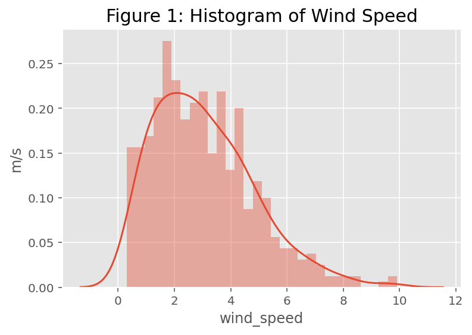

```python
plot1 = sns.distplot(data['wind_speed'], kde=True, bins = 30)
plot1.set(ylabel='m/s')
plt.title('Figure 1: Histogram of Wind Speed', fontsize = 15)
plt.show()
```

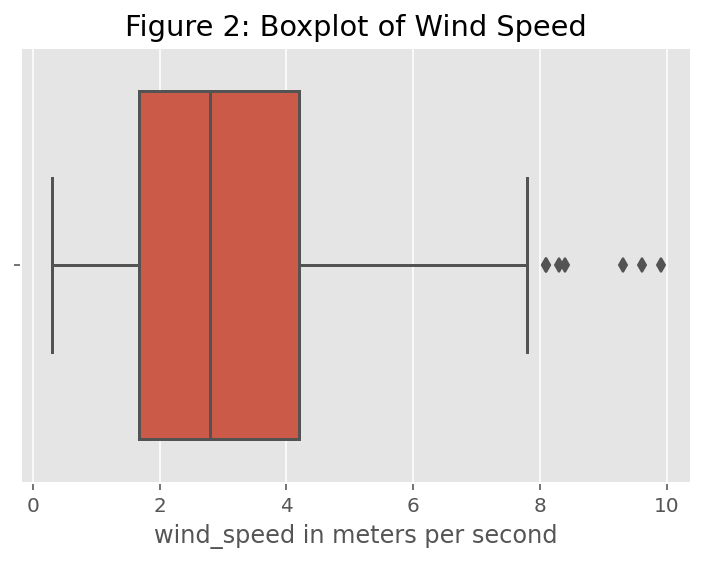

```
The wind_speed is right skewed with a mean of 3.056 metres per second and a few possible outliers
```

```python
sns.boxplot(x =data['wind_speed']).set(
    xlabel='wind_speed in meters per second', title = 'Figure 2: Boxplot of Wind Speed')
plt.show()
print(f'''The wind_speed is right skewed with a mean of {round(data['wind_speed'].mean(),4)} metres per second and a few possible outliers
''')
```

#### Difference between temperature at 2m and 25m

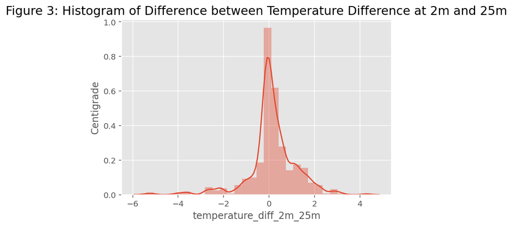

```python
plot2 = sns.distplot(data['temperature_diff_2m_25m'], kde=True, bins = 30)
plot2.set(ylabel = 'Centigrade')
plt.title('Figure 3: Histogram of Difference between Temperature Difference at 2m and 25m', fontsize = 15)
plt.show()
```

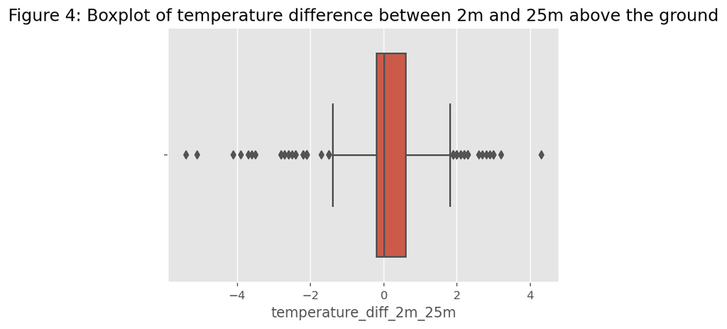

```
The temperature difference between 2 and 25m above the ground is right skewed with a mean of 0.1494 various outliers.
```

```python
sns.boxplot(x =data['temperature_diff_2m_25m']).set(xlabel='temperature_diff_2m_25m', title = 'Figure 4: Boxplot of temperature difference between 2m and 25m above the ground')
plt.show()
print(f'''The temperature difference between 2 and 25m above the ground is right skewed with a mean of {round(data['temperature_diff_2m_25m'].mean(),4)} various outliers.''')
```

#### Cars per hour

```python
print(f'''Approximately {round(data['cars_per_hour'].mean(),4)} cars drive through this path per hour
The interquartile range is from {round(data['cars_per_hour'].quantile(0.75),4)} to {round(data['cars_per_hour'].quantile(0.25),4)}
''')
```

```
Approximately 6.9733 cars drive through this path per hour
The interquartile range is from 7.7932 to 6.1758
```

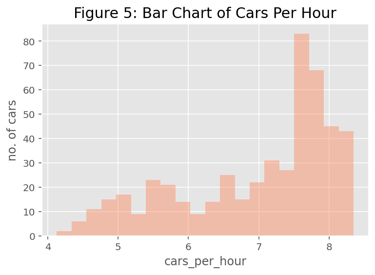

```python
plot3 = sns.distplot(data['cars_per_hour'], kde=False, bins = 20, color = 'coral')
plot3.set(ylabel = 'no. of cars')
plt.title('Figure 5: Bar Chart of Cars Per Hour', fontsize = 15)
plt.show()
```

The number of cars per hour is very clearly skewed to the left, indicating a greater probability of a larger volume of cars on the road. There are no outliers.

### Multivariate Visualisation

#### Scatterplot numeric features and NO2 Concentration

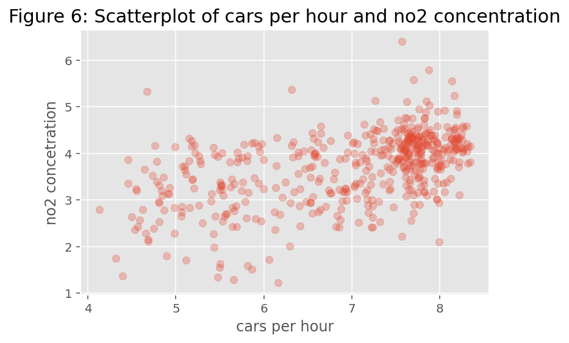

```python
cph = data['cars_per_hour']

plt.scatter(cph, data['no2_concentration'], alpha = 0.3)
plt.title('Figure 6: Scatterplot of cars per hour and no2 concentration', fontsize = 15)
plt.xlabel('cars per hour')
plt.ylabel('no2 concetration')
plt.show();
```

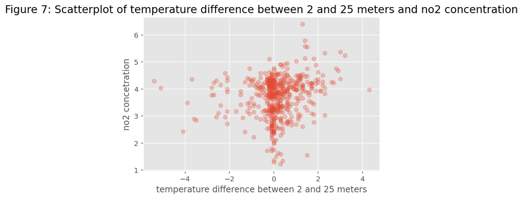

```python
tdiff = data['temperature_diff_2m_25m']

plt.scatter(tdiff, data['no2_concentration'], alpha = 0.3)
plt.title('Figure 7: Scatterplot of temperature difference between 2 and 25 meters and no2 concentration', fontsize = 15)
plt.xlabel('temperature difference between 2 and 25 meters')
plt.ylabel('no2 concetration')
plt.show();
```

## Statistical Modelling and Performance Evaluation

### Full Model

We begin by fitting a multiple linear regression that predicts `no2 concentration` using all of the avaliable features. We call this the full model. First let's take a quick peak at the clean data.

```python
data.head()
```

|  | no2_concentration | cars_per_hour | wind_speed | temperature_diff_2m_25m | wind_direction | hour_of_day |
| --- | --- | --- | --- | --- | --- | --- |
| 0 | 3.718 | 7.691 | 4.8 | -0.1 | 74.4 | 20 |
| 1 | 3.100 | 7.699 | 3.5 | -0.3 | 56.0 | 14 |
| 2 | 3.314 | 4.812 | 0.9 | -0.1 | 281.3 | 4 |
| 3 | 4.388 | 6.952 | 1.7 | 1.2 | 74.0 | 23 |
| 4 | 4.346 | 7.518 | 2.6 | -0.1 | 65.0 | 11 |

```python
formula_string_indep_vars = ' + '.join(data.drop(columns='no2_concentration').columns)
formula_string = 'no2_concentration ~ ' + formula_string_indep_vars
print('formula_string: ', formula_string)
```

```
formula_string:  no2_concentration ~ cars_per_hour + wind_speed + temperature_diff_2m_25m + wind_direction + hour_of_day
```

Adding the square of the cars_per_hour feature to illustrate the addition of higher order terms to our linear regression.

```python
formula_string = formula_string + ' + np.power(cars_per_hour, 2)'
print('formula_string: ', formula_string)
```

```
formula_string:  no2_concentration ~ cars_per_hour + wind_speed + temperature_diff_2m_25m + wind_direction + hour_of_day + np.power(cars_per_hour, 2)
```

```python
model_full = sm.formula.ols(formula=formula_string,data=data)
###
model_full_fitted = model_full.fit()
###
print(model_full_fitted.summary())
```

```
                            OLS Regression Results
==============================================================================
Dep. Variable:      no2_concentration   R-squared:                       0.489
Model:                            OLS   Adj. R-squared:                  0.482
Method:                 Least Squares   F-statistic:                     78.54
Date:                Sun, 01 Nov 2020   Prob (F-statistic):           1.13e-68
Time:                        10:29:20   Log-Likelihood:                -397.81
No. Observations:                 500   AIC:                             809.6
Df Residuals:                     493   BIC:                             839.1
Df Model:                           6
Covariance Type:            nonrobust
==============================================================================================
                                 coef    std err          t      P>|t|      [0.025      0.975]
----------------------------------------------------------------------------------------------
Intercept                      3.7361      1.070      3.492      0.001       1.634       5.839
cars_per_hour                 -0.4085      0.334     -1.224      0.222      -1.064       0.247
wind_speed                    -0.1407      0.014     -9.937      0.000      -0.169      -0.113
temperature_diff_2m_25m        0.1991      0.025      8.066      0.000       0.151       0.248
wind_direction                 0.0001      0.000      0.402      0.688      -0.000       0.001
hour_of_day                   -0.0159      0.005     -3.384      0.001      -0.025      -0.007
np.power(cars_per_hour, 2)     0.0681      0.025      2.714      0.007       0.019       0.117
==============================================================================
Omnibus:                       17.518   Durbin-Watson:                   2.284
Prob(Omnibus):                  0.000   Jarque-Bera (JB):               23.676
Skew:                          -0.320   Prob(JB):                     7.23e-06
Kurtosis:                       3.853   Cond. No.                     8.06e+03
==============================================================================

Warnings:
[1] Standard Errors assume that the covariance matrix of the errors is correctly specified.
[2] The condition number is large, 8.06e+03. This might indicate that there are
strong multicollinearity or other numerical problems.
```

The full model has an adjusted R-squared value of 0.482, which means that only 48.2% of the variance is explained by the model

Defining a new data frame for actual no2_concentration vs. predicted no2_concentration and the residuals for the full model. We will use this data frame when plotting predicted values and the regression residuals.

```python
residuals_full = pd.DataFrame({'actual': data['no2_concentration'],
                            'predicted': model_full_fitted.fittedvalues,
                            'residual': model_full_fitted.resid})
residuals_full.head(10)
```

|  | actual | predicted | residual |
| --- | --- | --- | --- |
| 0 | 3.718 | 3.617412 | 0.100588 |
| 1 | 3.100 | 3.858956 | -0.758956 |
| 2 | 3.314 | 3.169258 | 0.144742 |
| 3 | 4.388 | 3.829800 | 0.558200 |
| 4 | 4.346 | 3.960552 | 0.385448 |
| 5 | 4.160 | 4.168314 | -0.008314 |
| 6 | 4.013 | 3.337164 | 0.675836 |
| 7 | 2.152 | 2.705239 | -0.553239 |
| 8 | 3.157 | 3.364843 | -0.207843 |
| 9 | 2.380 | 2.947430 | -0.567430 |

Plotting actual no2_concentration values vs. predicted values.

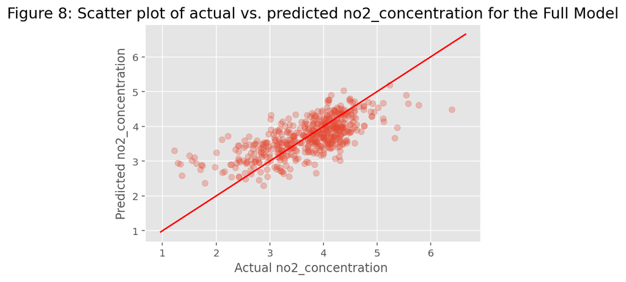

```python
def plot_line(axis, slope, intercept, **kargs):
    xmin, xmax = axis.get_xlim()
    plt.plot([xmin, xmax], [xmin*slope+intercept, xmax*slope+intercept], **kargs)

# Creating scatter plot
plt.scatter(residuals_full['actual'], residuals_full['predicted'], alpha=0.3);
plot_line(axis=plt.gca(), slope=1, intercept=0, c="red");
plt.xlabel('Actual no2_concentration ');
plt.ylabel('Predicted no2_concentration');
plt.title('Figure 8: Scatter plot of actual vs. predicted no2_concentration for the Full Model', fontsize=15);
plt.show();
```

From the Figure, we observe that the model never produces a prediction above 5.5 even though the highest no2_concentration in the dataset is above 6. We will now check the diagnostics for the full model.

### Full Model Diagnostic Checks

We would like to check whether there are indications of violations of the regression assumptions, which are: 1.Linearity of the relationship between target variable and the independent variables 2.Constant variance of the errors 3.Normality of the residual distribution 4.Statistical independence of the residuals

First we will get a scatter plot of residuals (as a function of predicted `no2_concentration`).

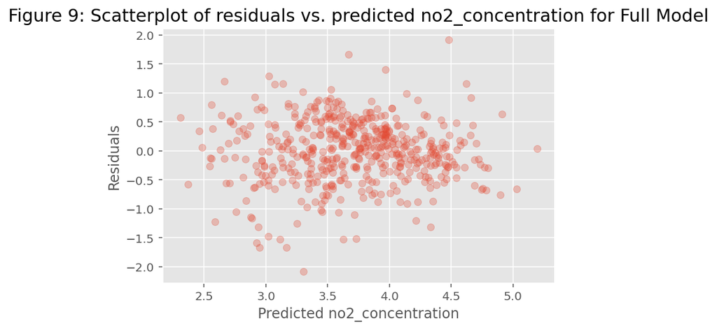

```python
plt.scatter(residuals_full['predicted'], residuals_full['residual'], alpha=0.3);
plt.xlabel('Predicted no2_concentration');
plt.ylabel('Residuals')
plt.title('Figure 9: Scatterplot of residuals vs. predicted no2_concentration for Full Model', fontsize=15)
plt.show();
```

From the above figure we see it exhibits mostly random pattern.

Now we will get a scatterplot of residuals vs. actual no2_concentration.

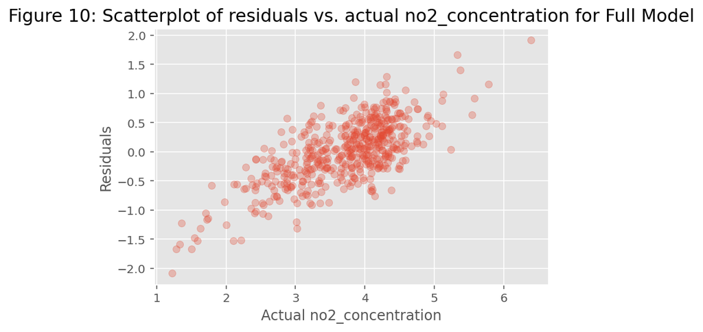

```python
plt.scatter(residuals_full['actual'], residuals_full['residual'], alpha=0.3);
plt.xlabel('Actual no2_concentration');
plt.ylabel('Residuals')
plt.title('Figure 10: Scatterplot of residuals vs. actual no2_concentration for Full Model', fontsize=15)
plt.show();
```

Let's overlay the histograms of actual vs. predicted no2_concentration on the same plot.

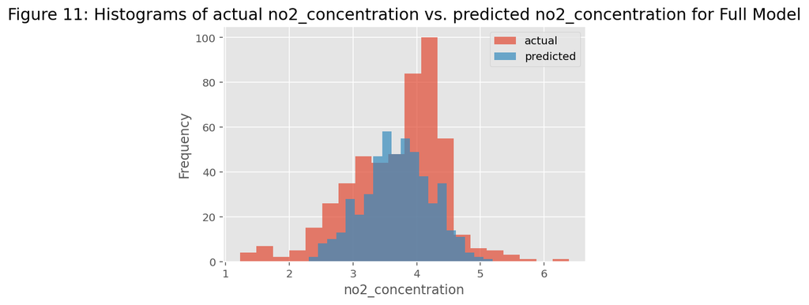

```python
plt.hist(residuals_full['actual'], label='actual', bins=20, alpha=0.7);
plt.hist(residuals_full['predicted'], label='predicted', bins=20, alpha=0.7);
plt.xlabel('no2_concentration');
plt.ylabel('Frequency');
plt.title('Figure 11: Histograms of actual no2_concentration vs. predicted no2_concentration for Full Model', fontsize=15);
plt.legend()
plt.show();
```

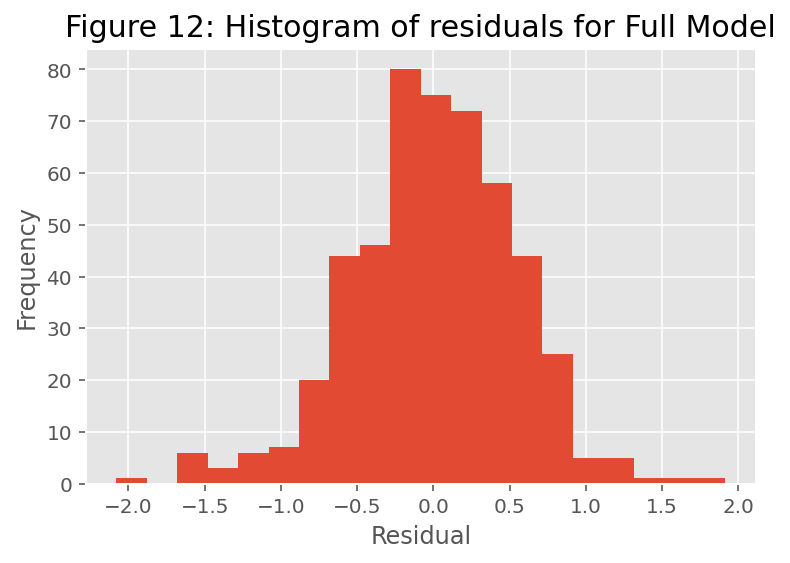

```python
plt.hist(residuals_full['residual'], bins = 20);
plt.xlabel('Residual');
plt.ylabel('Frequency');
plt.title('Figure 12: Histogram of residuals for Full Model', fontsize=15);
plt.show();
```

From Figure above, the histogram of residuals looks somewhat symmetric, though slightly left-skewed

### Backwards Feature Selection

We now perform backwards feature selection using p-values.

```python
patsy_desc = patsy.ModelDesc.from_formula(formula_string)
linear_reg_fit = model_full_fitted

#using a 5% significance level
cutoff_for_pval = 0.05

print(f'''Performing Backwards Feature Selection to obtain a model that only contains significant variables :''')
while True:
    #print(linear_reg_fit.summary())
    pval_series = linear_reg_fit.pvalues.drop(labels = 'Intercept')
    pval_series = pval_series.sort_values(ascending=False)
    term = pval_series.index[0]
    pval = pval_series[0]
    if (pval < cutoff_for_pval):
        break
    term_components = term.split(':')
    print(f'\nRemoving term "{term}" with p-value {pval:.5}')

    #checking if term is a main effect or interaction term
    if (len(term_components) == 1):
        patsy_desc.rhs_termlist.remove(patsy.Term([patsy.EvalFactor(term_components[0])]))
    else:
        patsy_desc.rhs_termlist.remove(patsy.Term([patsy.EvalFactor(term_components[0]),
                                                        patsy.EvalFactor(term_components[1])]))

    linear_reg_fit = smf.ols(formula=patsy_desc, data = data).fit()


model_reduced_fitted = smf.ols(formula = patsy_desc, data = data).fit()

print(f'''\nFit after backwards elimination :
***{model_reduced_fitted.summary()}***)
Regression number of terms: {len(model_reduced_fitted.model.exog_names)}
Regression F-distribution p-value: {model_reduced_fitted.f_pvalue:.5f}
Regression R-squared: {model_reduced_fitted.rsquared:.5f}
Regression Adjusted R-squared: {model_reduced_fitted.rsquared_adj:.5f}''')
```

```
Performing Backwards Feature Selection to obtain a model that only contains significant variables :

Removing term "wind_direction" with p-value 0.68781

Removing term "cars_per_hour" with p-value 0.21957

Fit after backwards elimination :
***                            OLS Regression Results
==============================================================================
Dep. Variable:      no2_concentration   R-squared:                       0.487
Model:                            OLS   Adj. R-squared:                  0.483
Method:                 Least Squares   F-statistic:                     117.5
Date:                Sun, 01 Nov 2020   Prob (F-statistic):           2.20e-70
Time:                        10:29:21   Log-Likelihood:                -398.65
No. Observations:                 500   AIC:                             807.3
Df Residuals:                     495   BIC:                             828.4
Df Model:                           4
Covariance Type:            nonrobust
==============================================================================================
                                 coef    std err          t      P>|t|      [0.025      0.975]
----------------------------------------------------------------------------------------------
Intercept                      2.4490      0.100     24.434      0.000       2.252       2.646
wind_speed                    -0.1408      0.014    -10.075      0.000      -0.168      -0.113
temperature_diff_2m_25m        0.1986      0.025      8.056      0.000       0.150       0.247
hour_of_day                   -0.0179      0.004     -4.088      0.000      -0.027      -0.009
np.power(cars_per_hour, 2)     0.0376      0.002     17.322      0.000       0.033       0.042
==============================================================================
Omnibus:                       20.502   Durbin-Watson:                   2.285
Prob(Omnibus):                  0.000   Jarque-Bera (JB):               29.830
Skew:                          -0.339   Prob(JB):                     3.33e-07
Kurtosis:                       3.986   Cond. No.                         223.
==============================================================================

Warnings:
[1] Standard Errors assume that the covariance matrix of the errors is correctly specified.***)
Regression number of terms: 5
Regression F-distribution p-value: 0.00000
Regression R-squared: 0.48698
Regression Adjusted R-squared: 0.48284
```

```python
residuals_reduced = pd.DataFrame({'actual': data['no2_concentration'],
                            'predicted': model_full_fitted.fittedvalues,
                            'residual': model_full_fitted.resid})
residuals_reduced.head(10)
```

|  | actual | predicted | residual |
| --- | --- | --- | --- |
| 0 | 3.718 | 3.617412 | 0.100588 |
| 1 | 3.100 | 3.858956 | -0.758956 |
| 2 | 3.314 | 3.169258 | 0.144742 |
| 3 | 4.388 | 3.829800 | 0.558200 |
| 4 | 4.346 | 3.960552 | 0.385448 |
| 5 | 4.160 | 4.168314 | -0.008314 |
| 6 | 4.013 | 3.337164 | 0.675836 |
| 7 | 2.152 | 2.705239 | -0.553239 |
| 8 | 3.157 | 3.364843 | -0.207843 |
| 9 | 2.380 | 2.947430 | -0.567430 |

[figure not shown]

```python
# get a scatter plot
plt.scatter(residuals_reduced['actual'], residuals_reduced['predicted'], alpha=0.3);
plot_line(axis=plt.gca(), slope=1, intercept=0, c="red");
plt.xlabel('NO2 Concentration');
plt.ylabel('NO2 Concentration');
plt.title('Figure 13: Scatter plot of actual vs. predicted age for Reduced Model', fontsize=15);
plt.show();
```

### Reduced Model Diagnostic Checks

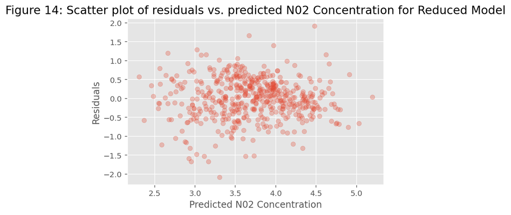

```python
plt.scatter(residuals_reduced['predicted'], residuals_reduced['residual'], alpha=0.3);
plt.xlabel('Predicted N02 Concentration');
plt.ylabel('Residuals')
plt.title('Figure 14: Scatter plot of residuals vs. predicted N02 Concentration for Reduced Model', fontsize=15)
plt.show();
```

Let's now have look at the histogram of the residuals for the reduced model.

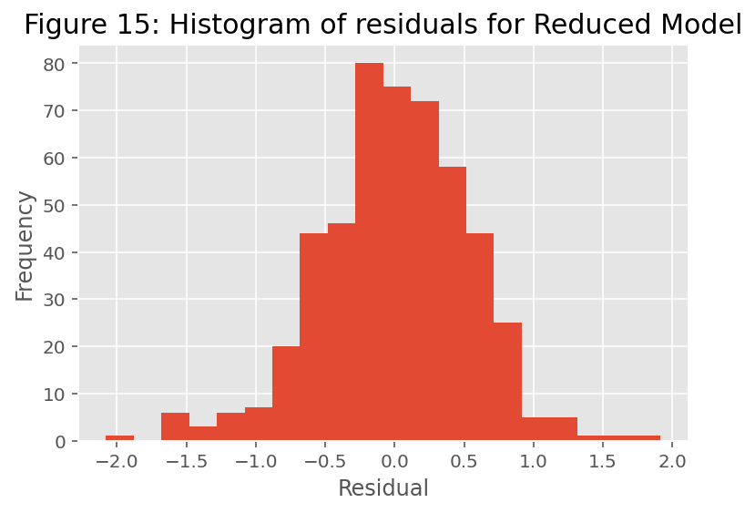

```python
plt.hist(residuals_reduced['residual'], bins = 20);
plt.xlabel('Residual');
plt.ylabel('Frequency');
plt.title('Figure 15: Histogram of residuals for Reduced Model', fontsize = 15)
plt.show();
```

From the Figure above, there is again a somewhat symmetric histogram around zero, which suggests that the residuals are somewhat normally distributed.

## Summary and Conclusions

The full model produced using all the independent variables in our dataset gives a model with an adjusted R-squared value of $48.2\%$. On elimination of two independent variables using the backwards feature selection process we are still able to maintain the same performance with a new adjusted R-squared value of $48.3\%$. The final model thus has 5 variables in total with a p-value equal to zero.

The histogram for residuals of reduced model verifies that the residuals are distributed normally and somewhat symmetrically. This is supported by the scatter plot that shows that the residuals are mostly clustered between $-1.0$ and $1.0$.

The model does not predict any values above approximately $5.5$ particles of Nitrogen Dioxide in the air even when the values are above $6$. The model is otherwise quite consistent in predicting the values of Nitrogen Dioxide concentration with an approximate margin of error, less than $\pm2.0$. The margin of error can be concluded as quite significant given the scale and nature of data to be predicted.

The adjusted r-squared value of the final model however is only $48.3\%$, which is significantly low for the prediction of a physical process. Since the adjusted r-sqaured value measures the explanatory power of the independent variables used in the regression model, we can thus conclude that the meteorological and traffic based variables available in this dataset cannot be used to reliably predict the hourly concentration of nitrogen dioxide in the air using multiple linear regression.

## References

- Aldrin, M. (2004). Open Machine Learning Repository [online]. Available at https://www.openml.org/d/547 [Accessed 2020-09-15]